# Introducción a R y Rstudio

Profesores: Carlos M. González Alcón - Carlos Pérez González  
(Dpto. de Matemáticas, Estadística e Investigación Operativa - Universidad de La Laguna)

Introducción a la interfaz Rstudio.

# 1. Introducción a la interfaz Rstudio.

## Contenidos

- ¿Qué es RStudio?
- Vistazo rápido y características de RStudio
- Instalación de RStudio
- Descripción del entorno
- Cargar datos en Rstudio
- Datos cargados en RStudio
- Guardar datos en formato CSV
- El directorio de trabajo
- Gestión del historial
- Primer script en RStudio
- Usando la ayuda
- Extracción y ejecución de funciones
- Ejecutando funciones propias
- Secciones, plegado y navegación de código
- Navegación de código
- Visualización de datos
- Instalación de paquetes en RStudio
- Opciones de la pestaña **Plot**
- El comando `manipulate`
- Ejercicios
- Otros aspectos de R
- Proyecto dentro de RStudio
- Atajos de teclado
- Referencias

# ¿Qué es RStudio?

- RStudio es una herramienta **IDE (*Integrated Development Environment*)** para **R**, libre y gratuita que facilita:
- Trabajar con R y gráficos de R de forma interactiva.
- Organizar el código y mantener múltiples proyectos.
- Gestión de los paquetes de R (instalación, actualización,..).
- Crear y compartir informes (utilizando un lenguaje llamado markdown).
- Compartir código y colaborar con otros usuarios.
- RStudio también se ofrece como herramienta comercial para empresas (ofreciendo la empresa desarrolladora servicios adicionales de consultoría y formación).
- RStudio **NO** realiza ninguna operación estadística. Solo facilita realizar dichas operaciones sobre R.

[figure not shown]

# Instalación de RStudio

- Antes de instalar RStudio, necesitas instalar **R**. Se puede obtener desde:
- cran.r-project.org
- Una vez instalado R, se puede instalar RStudio en tu ordenador (versión **Desktop**) dependiendo del sistema operativo:
- www.rstudio.com/ide/download/desktop
- Solo en Linux, también se puede instalar **RStudio Server**, el cual permite acceder al entorno desde un navegador web:
- www.rstudio.com/ide/server

# Características de Rstudio

- Integración de la consola de R dentro de Rstudio (se pueden teclear comandos de R directamente).
- Ejecución de código (permite ejecutar código directamente desde un fichero de script).
- Resaltado de la sintaxis (realiza una coloración automática de los instrucciones y de las funciones).
- Ayuda con los paréntesis, corchetes y comillas (autocompleta estos símbolos al abrirlos).
- Completado de comandos (completa los comandos mientras se escriben usando la tecla `Tab`).
- Atajos de teclado (al final de la presentación).
- Navegador de objetos (se pueden inspeccionar todos los objetos de la sesión de R).
- Gestión del historial de comandos.
- Navegación del código en la ventana de script (mediante secciones que finalizan en `----`).
- Importación y visualización de datos.
- Integración de gráficos (manipulación, zoom y exportación).
- Otros aspectos destacables son la gestión de proyectos (se puede cambiar de un proyecto a otro fácilmente), el control de versiones (se integra bien con `git` y `svn`) y la generación de documentos (tipo PDF, HTML y otros más avanzados con un solo click).

# Descripción del entorno

[figure not shown]

# Cargar datos en Rstudio

# El fichero `ddt.txt`

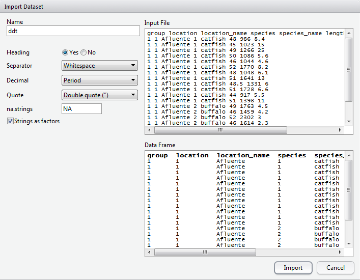

- RStudio deduce casi todas las opciones de importación:
- **Heading**: si trae el nombre de la variable.
- **Separator**: tipo de separador entre datos.
- **Decimal**: símbolo para el punto decimal.
- **Quote**: símbolo para los comentarios.
- Al final, los datos se cargan en un `data.frame` de R con el mismo nombre que el fichero de datos (`ddt`).

# Datos cargados en RStudio

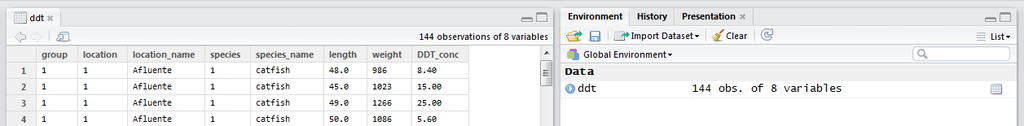

- Los datos cargados se muestran en el panel superior izquierdo, y en el panel de espacio de trabajo (o entorno).
- Vamos a guardar estos datos en un fichero CSV (*comma separated values*).
- Para ello, empezaremos a usar la consola de R, y las funciones incorporadas de completado de comandos y de nombres de carpetas/ficheros.

# Guardar datos en formato CSV

- Tecleamos el comando `write` en la consola R, y pulsamos la tecla de tabulación `Tab`:

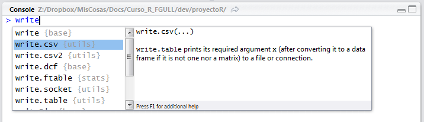

- La característica de RStudio que hemos usado se denomina **completado de comandos**.
- De las opciones que nos ofrece, seleccionamos `write.csv`, y seguimos escribiendo un paréntesis `(`, que RStudio completará con otro párentesis `)`.
- Continuamos escribiendo el comando, indicando en el primer parámetro el objeto `ddt`, y en el segundo parámetro, el nombre del fichero a guardar.
- La función que hemos usado ahora se denomina **completado de carpetas/ficheros**.
- Como nombre del fichero, ponemos el nombre `ddt.csv`.
- Terminamos de escribir el comando con el último parámetro, para indicar que no queremos que guarde el nombre (número) de cada fila:

```r
write.csv(ddt, "ddt.csv", row.names=FALSE)
```

# El directorio de trabajo

- Si no lo hemos configurado previamente, este archivo csv no se ha copiado en el directorio `cursoR`.
- En R (y Rstudio), existe lo que se conoce como **directorio de trabajo** y que representa el directorio donde (por defecto) se cargan, se graban, etc.. los archivos en caso de no especificar una ruta (path) para el archivo.
- Este directorio se consulta con el comando `getwd()`. Si queremos cambiarlo utiliamos el comando `setwd(ruta_a_carpeta)`.
- En Rstudio lo cambiamos fácilmente en la opción `More` de la ventana de ficheros, una vez que nos hemos situado dentro del directorio deseado.

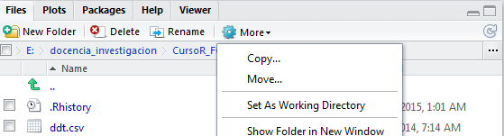

- También podemos especificar la ruta de búsqueda del fichero en `write.csv` pulsando `Tab` en el segundo argumento de la función.
- Podemos ver el fichero creado, y haciendo clic sobre él, nos mostrará el contenido:

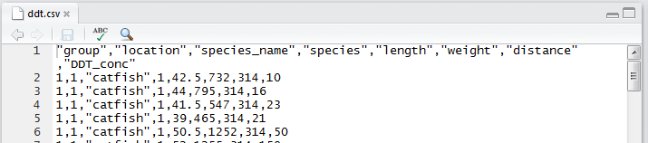

# Gestión del historial

- Hay tres formas para re-usar los comandos ya tecleados en RStudio:
- Pulsando las teclas de fecla arriba o abajo.
- Pulsando **Ctrl+▲**.

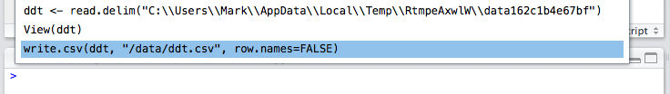

- Explorando la pestaña **History** en el panel derecho superior:

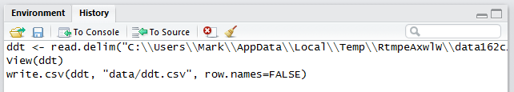

- Se puede seleccionar un comando o varios (usando la tecla `Shift`=`Mayúsc`), y ejecutar pulsando `Enter`.
- Asimismo, se pueden salvar a un fichero llamado `.Rhistory`, en la carpeta del proyecto.
- También se pueden pasar a la consola con el comando **To Console** para ser ejecutados, o a un script directamente con el botón **To Source**.
- Por último, se pueden eliminar con la tecla `Supr` (`Del`) o con el botón correspondiente, o borrar completamente todo el historial con el botón de la escoba.

# Primer script R en RStudio

- Una vez cargados los datos, vamos a escribir el primer script en lenguaje R para hacer un primer análisis.
- Hacemos click en el icono **+** verde del editor de scripts (izquierdo superior), y elegimos **R Script**.

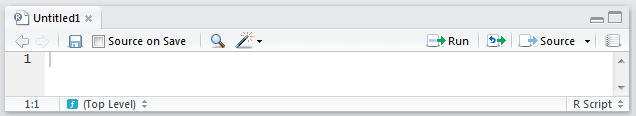

- Las acciones más interesantes sobre un script de R son:
- **Disco**: salvar el fichero.
- **Lupa**: buscar y reemplazar.
- **Varita mágica**: herramientas útiles (algunas las veremos luego).
- **Run**: ejecuta el código seleccionado (**Ctrl+Enter**).
- **Re-Run**: ejecuta el último código que seleccionamos.
- **Cuaderno**: compila el script R a un fichero HTML (lo veremos luego).
- Las opciones del tipo **Source** sirven para cargar el código fuente al espacio de trabajo de R (lo veremos luego).
- Vamos a introducir los primeros comandos R en el script:

```r
# estructura de los datos
str(ddt)

# resumen de los datos
summary(ddt)
```

- Guardamos este script pulsando el botón del disco (arriba), o en el menú **File > Save**, con el nombre `funciones.R` en el directorio `R` de nuestro proyecto.

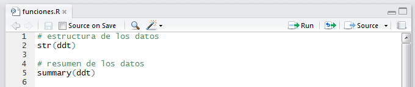

- Una vez guardado, podemos ejecutar el script de varias formas:
- Sobre la línea en la que estamos, pulsamos el botón **Run** o **Ctrl+Enter**.
- O seleccionamos todo el script, y hacemos lo mismo que en el punto anterior.

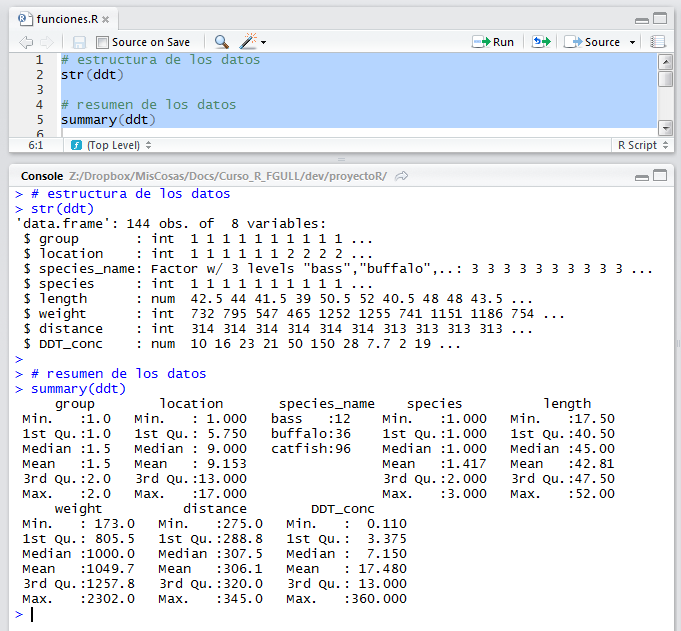

# Usando la ayuda

- Ahora es buen momento para empezar a usar la ayuda para, por ejemplo, el comando `summary`:

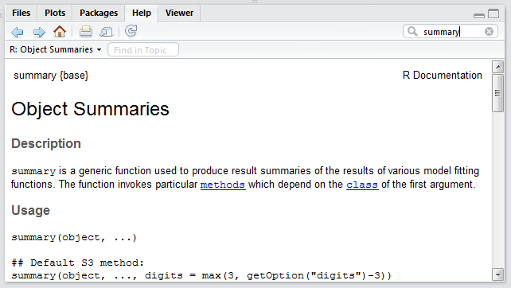

# Extracción de funciones

- Una de las características más interesantes de RStudio es la posibilidad de crear funciones a partir de trozos de código.
- Por ejemplo, vamos a crear una función llamada `Resumen`, que recibe un parámetro `datos`, y ejecuta los dos comandos que acabamos de escribir.
- Para ello, cambiamos `ddt` por `datos` en ambos comandos.
- Seleccionamos las líneas del código.
- Pulsamos sobre la “varita mágica” en la opción **Extract Function**, y le damos el nombre `Resumen`.

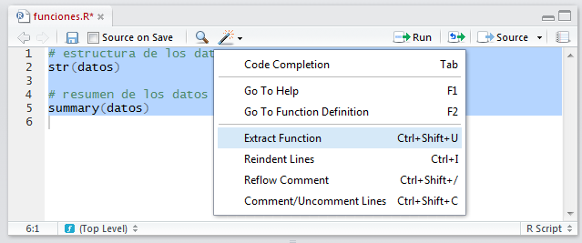

- Añadimos finalmente un comentario para describir el objetivo de la función.
- Por último, salvamos el script.

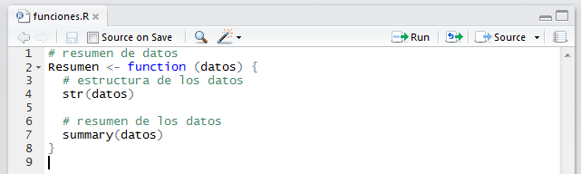

# Ejecutando funciones propias

- Si tecleamos la siguiente línea en la consola de R, nos dará un error:

```r
Resumen(ddt)
```

```
## Error in Resumen(ddt): no se pudo encontrar la función "Resumen"
```

- Esto sucede porque la función Resumen no ha sido cargada (*sourced*) al entorno o espacio de trabajo de nuestro proyecto.
- Para poder usar la función `Resumen(datos)` tenemos que hacer lo siguiente:

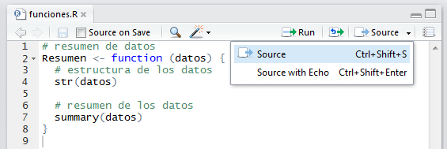

- Si hubiéramos elegido la opción **Source with Echo**, obtendríamos el mismo resultado además de mostrar todo el código cargado.
- Las funciones cargadas aparecen, al igual que los datos, en el panel derecho superior de **Environment**, en la sección de **Functions**.
- Ya podemos usar nuestra nueva función `Resumen` pasándole como parámetro los datos de `ddt`:

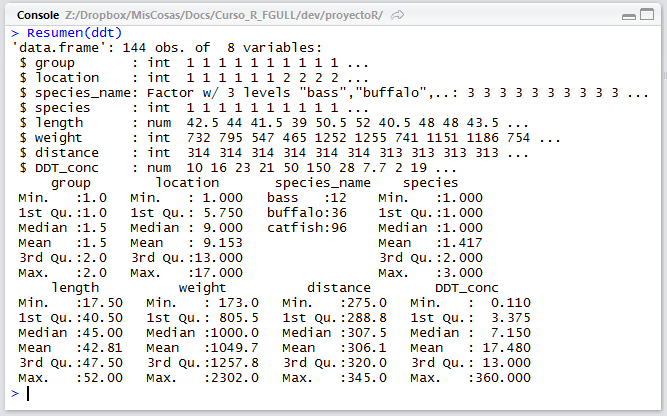

- Si vamos a estar cambiando la función continuamente, podemos activar la opción **Source on Save** para que la cargue al entorno automáticamente después de salvar el script.

# Secciones del código

- Otra característica interesante de RStudio (y no de R) es la posibilidad de estructurar el código en secciones.
- Las secciones se pueden crear desde el menú **Code > Insert Section**, o simplemente poniendo un comentario (`#`) con un nombre de sección y acabado en 4 guiones (`----`):

```
# <NombreDeLaSección> ----
```

- Podemos aprovechar el comentario de la función Resumen para hacer nuestra primera sección:

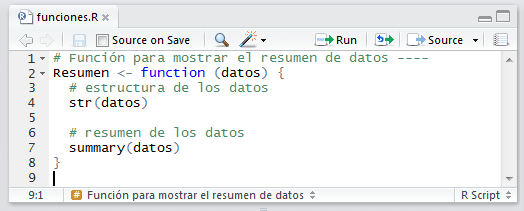

- Fíjense que dicha sección aparece en la parte inferior del editor como **navegación del código**, que luego veremos.

# Plegado de código/secciones

- Otra característica muy útil de RStudio es el plegado de las secciones o de partes del código que estén rodeadas por llaves `{}`.
- Al plegarse aparecerá un pequeño triángulo que permite colapsar o expandir el bloque de código.

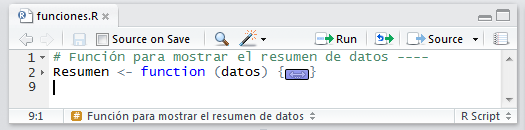

# Navegación de código

- La navegación de código en RStudio es una utilidad que permite editar el código de forma más rápida.
- Se puede acceder a una línea concreta pulsando **Alt+Shift+G**, o en el menú **Edit > Go to Line…**
- Con la opción **Code > Jump To…** (**Alt+Shift+J**) se puede saltar directamente a funciones o secciones del código.

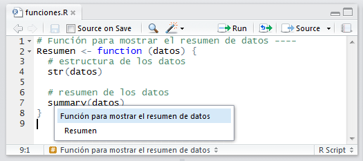

- Otra opción muy útil es la de ir a un fichero/función determinado usando **Code > Go To File/Function** (**Ctrl+.**). RStudio mostrará todos los ficheros o funciones dentro del directorio de trabajo que empiecen con los caracteres tecleados.

# Visualización de datos

- La visualización (o dibujado de gráficos) es una parte esencial del análisis de datos. RStudio tiene un panel específico para la visualización de datos (**Plots**) abajo a la derecha.
- Para ilustrar el manejo de las instrucciones de visualización, vamos a usar escribir el siguiente código dentro de nuestro script de R debajo de la función `Resumen`:

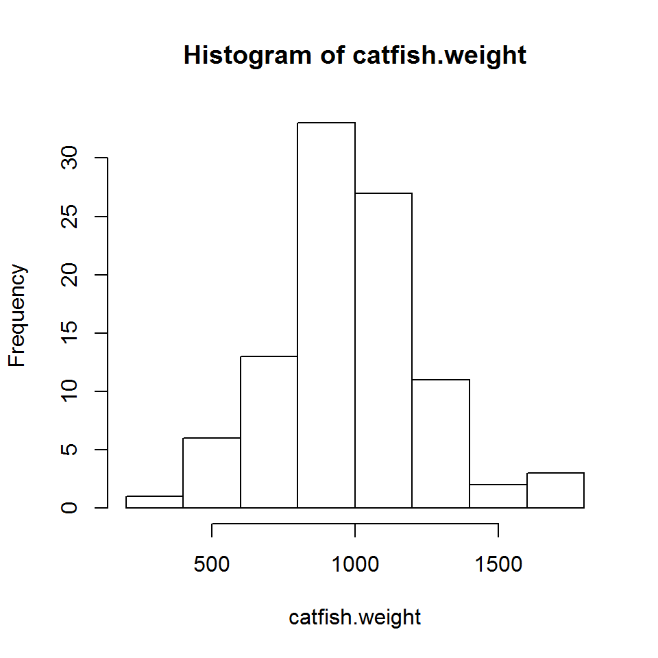

```r
# cargamos los datos del fichero
ddt  <- read.csv("ddt.txt",sep="")

# pesos de la especie “catfish”
catfish.weight  <- ddt$weight[ddt$species_name == "catfish"]

# histograma del peso de los “catfish”
hist(catfish.weight)
```

- Al teclear `ddt$` podemos pulsar la tecla `Tab` para que nos muestre la lista de variables de ddt. Esto se denomina **completado de objetos**.

# Instalación de paquetes en RStudio

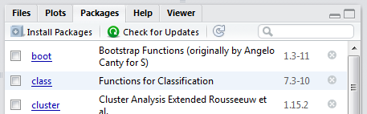

- **Check for Updates**: permite actualizar los paquetes a sus últimas versiones.
- **Install Packages**: permite instalar paquetes desde **CRAN** (repositorio).

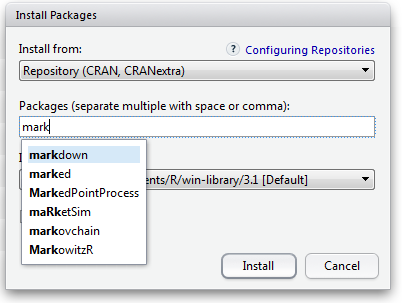

- Se puede conseguir el mismo efecto con el siguiente comando:

```r
install.packages("<Nombre_de_la_librería>")
```

# Opciones de la pestaña **Plot**

- Con la opción **Zoom** se abre una nueva ventana con una versión más grande del gráfico.
- El botón **Export** nos permite guardar el gráfico como una imagen en varios formatos (PNG, JPEG, TIFF, etc) o como un fichero PDF.
- También podemos copiar el gráfico actual al portapapeles del sistema.
- En caso de haber generado varios gráficos, las flechas permiten avanzar o retroceder en la visualización de dichos gráficos.

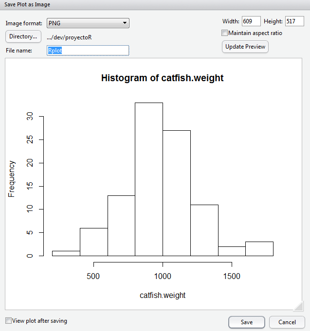

# El comando `manipulate`

- RStudio permite controlar de forma dinámica los gráficos generados con R.
- El comando que permite la interactividad entre el usuario y los gráficos generados.
- Las opciones de controles que permite `manipulate`:
- `slider`: control para un rango (min, max) numérico.
- `picker`: control sobre un conjunto de opciones fijas.
- `checkbox`: control de casilla de verificación.
- `button`: control de botón.
- Vamos a ver un pequeño ejemplo:

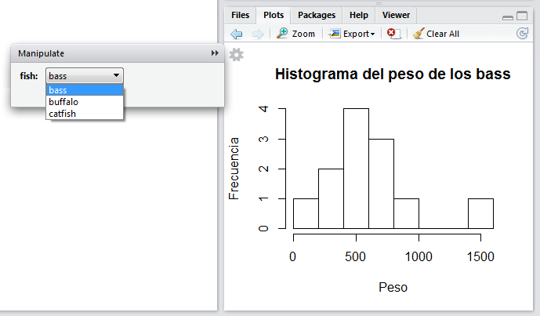

```r
# control de selección para elegir la especie de pez
library(manipulate)
manipulate(
  hist(ddt$weight[ddt$species_name == fish], xlab="Peso", ylab="Frecuencia",
       main=paste("Histograma del peso de los", fish)),
  fish = picker("bass", "buffalo", "catfish")
  )
```

# Ejercicios

1. Hacer una función que use el comando `manipulate` sobre el comando `qplot`para que el usuario elija la especie sobre la cual quiere comparar la longitud (`length`) contra el peso (`weight`).

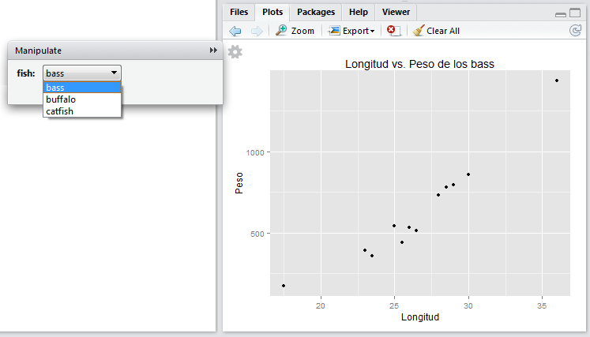